# Trees and Forests

```r
#data

#regression
housing  <- read.csv("data/housing.csv.gz")#https://www.kaggle.com/camnugent/california-housing-prices

data(Boston, package="MASS")
set.seed(1)
train = sample(1:nrow(Boston), nrow(Boston)/2)
boston.train=Boston[train,]
boston.test=Boston[-train,]

#classification
data(SAheart, package = "ElemStatLearn")

Titanic <- read.csv("data/TitanicTrain.csv")
Titanic$Survived = factor(Titanic$Survived)
Titanic$Pclass = factor(Titanic$Pclass)
```

# Pruning and Cross Validation

The Rpart implementation first fits a fully grown tree on the entire data $D$ with $T$ terminal nodes. After this step, the tree is pruned to the smallest tree with lowest miss-classification loss. This is how it works:

1. The data is then split into $n$ (default = 10) randomly selected folds: $F_1$ to $F_{10}$
2. It then uses 10-fold cross-validation and fits each sub-tree $T_1 … T_m $ on each training fold $D_s$.
3. The corresponding miss-classification loss (risk) $R_m$ for each sub-tree is then calculated by comparing the class predicted for the validation fold vs. actual class; and this risk value for each sub-tree is summed up for all folds.
4. The complexity parameter $\beta$ giving the lowest total risk over the whole dataset is finally selected.
5. The full data is then fit using this complexity parameter and this tree is selected as the best trimmed tree.

Hence, when you use `plotcp`, it plots the relative cross-validation error for each sub-tree from smallest to largest to let you compare the risk for each complexity parameter $\beta$.

# Regression Trees

## Boston

### rpart

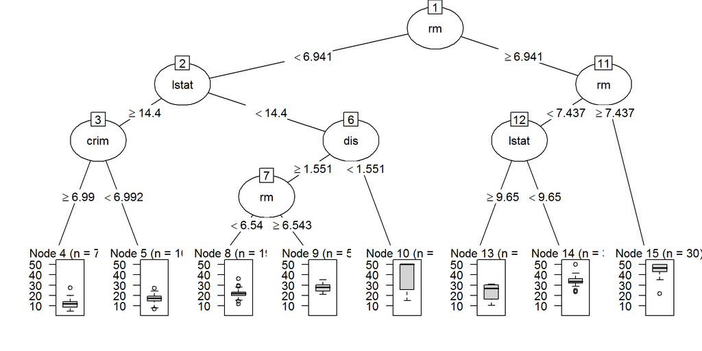

```r
fit1=rpart(medv ~ .,Boston)
plot(as.party(fit1))
```

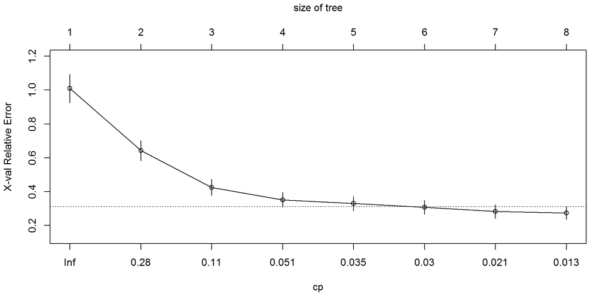

```r
plotcp(fit1)
```

### partykit

[figure not shown]

```r
fit2=ctree(medv ~ .,Boston)
plot(fit2)
```

## CA Housing data

### rpart

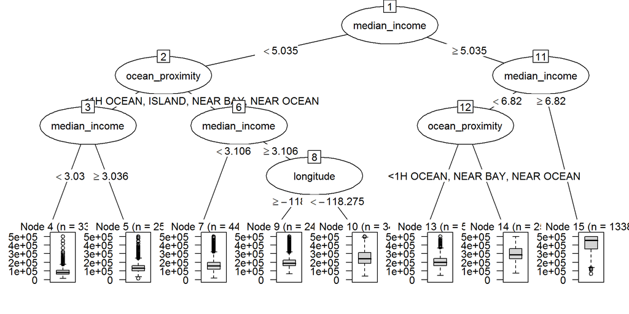

```r
fit1=rpart(median_house_value ~ .,housing)
plot(as.party(fit1))
```

### partykit

```r
fit2=ctree(median_house_value ~ .,housing)
plot(fit2)
```

[output not shown]

# Classification Trees

## Titanic

### rpart

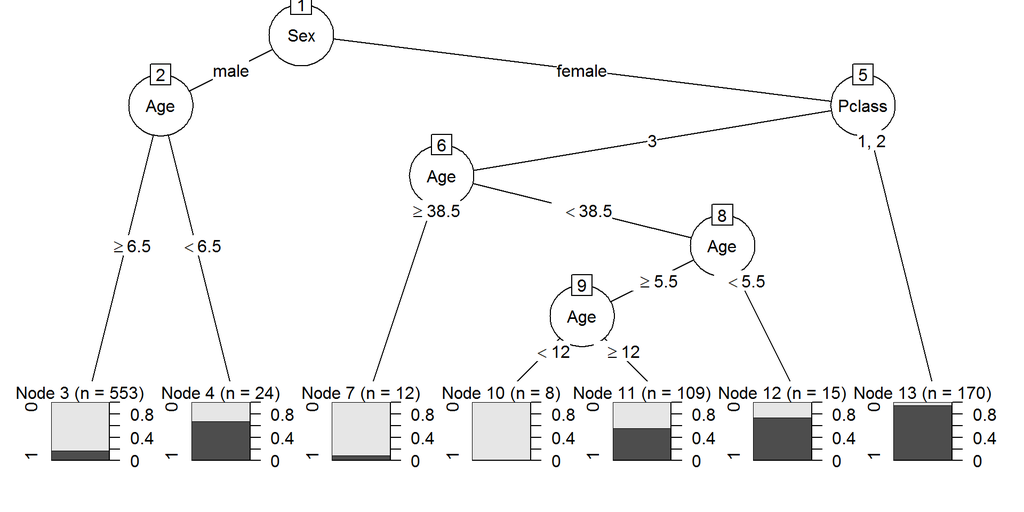

```r
fit1=rpart(Survived ~ Sex + Age + Pclass,Titanic)
plot(as.party(fit1))
```

### ctree

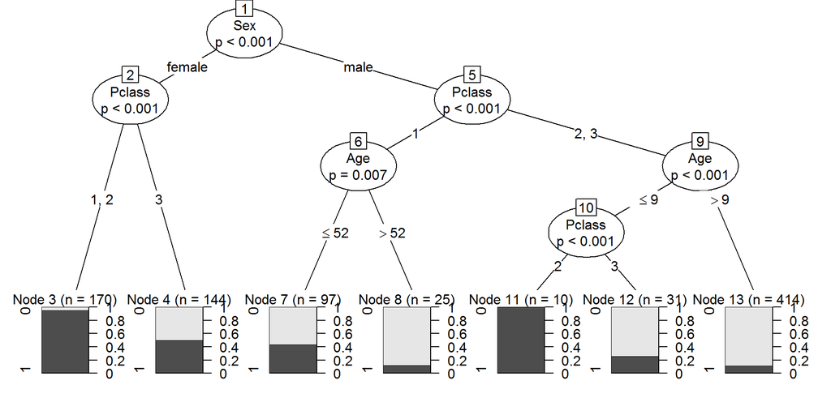

```r
fit2=ctree(Survived ~ Sex + Age + Pclass,Titanic)
plot(fit2)
```

Why does the tree not split any more on females in classes 1 and 2 ?

## Heart data

### rpart

[figure not shown]

```r
fit1=rpart(chd ~ .,SAheart)
plot(as.party(fit1))
```

### ctree

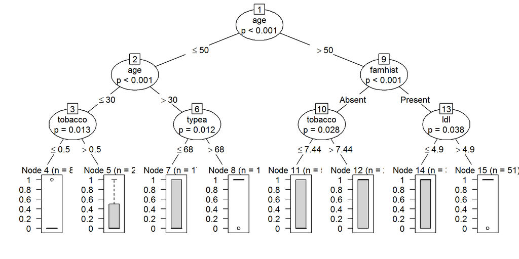

```r
fit2=ctree(chd ~ .,SAheart)
plot(fit2)
```

# Bagged Trees

## Housing

## Heart

# Random Forests

## Boston

```r
library(randomForest)
set.seed(1)

rf.boston=randomForest(medv~.,data=boston.train,mtry=6,importance=TRUE)
yhat.rf = predict(rf.boston,newdata=boston.test)
mean((yhat.rf-boston.test)^2)
```

```
## [1] 21254.65
```

```r
importance(rf.boston)
```

```
##           %IncMSE IncNodePurity
## crim    12.547772    1094.65382
## zn       1.375489      64.40060
## indus    9.304258    1086.09103
## chas     2.518766      76.36804
## nox     12.835614    1008.73703
## rm      31.646147    6705.02638
## age      9.970243     575.13702
## dis     12.774430    1351.01978
## rad      3.911852      93.78200
## tax      7.624043     453.19472
## ptratio 12.008194     919.06760
## black    7.376024     358.96935
## lstat   27.666896    6927.98475
```

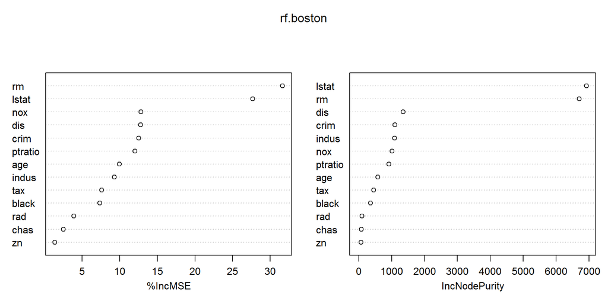

```r
varImpPlot(rf.boston)
```

##### Change a few parameters and explore the prediction error

##### Compare the test set prediction error with the OOB estimates

```r
rf.boston2=randomForest(medv~.,data=boston.train,mtry=3,ntree = 500,importance=TRUE)
yhat.rf = predict(rf.boston2,newdata=boston.test)
mean((yhat.rf-boston.test)^2)
```

```
## [1] 21255.36
```

```r
rf.boston2$predicted
```

[output not shown]

[output cut: 19 more lines]

[output not shown]

##### Change the code above so that instead of random forests the model is just bagged trees.

## Housing

## Heart

### h2o

# Boosting

## Boston

Here we use the gbm package, and within it the gbm() function, to fit boosted regression trees to the Boston data set. We run gbm() with the option distribution=“gaussian” since this is a regression problem; if it were a binary classification problem, we would use distribution=“bernoulli”. The argument n.trees=1000 indicates that we want 1000 trees, and the option interaction.depth=4 limits the depth of each tree.

```r
library(gbm)
set.seed(1)
boost.boston=gbm(medv~.,data=boston.train,distribution="gaussian",n.trees=1000,interaction.depth=4)
```

The summary() function produces a relative influence plot and also outputs the relative influence statistics.

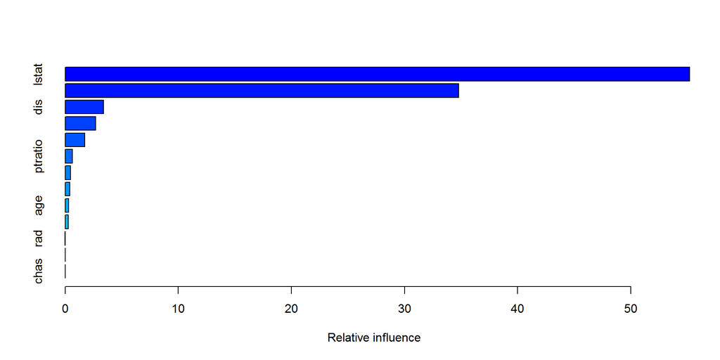

```
##             var      rel.inf
## lstat     lstat 55.200281457
## rm           rm 34.790172668
## dis         dis  3.409452074
## crim       crim  2.712680195
## nox         nox  1.721834165
## ptratio ptratio  0.659819879
## indus     indus  0.491659495
## tax         tax  0.399536401
## age         age  0.296293759
## black     black  0.281078428
## rad         rad  0.023465132
## zn           zn  0.008484369
## chas       chas  0.005241977
```

```r
summary(boost.boston)
```

We see that lstat and rm are by far the most important variables. We can also produce *partial dependence plots* for these two variables. These plots illustrate the marginal effect of the selected variables on the response after integrating out the other variables. In this case, as we might expect, median house prices are increasing with rm and decreasing with lstat.

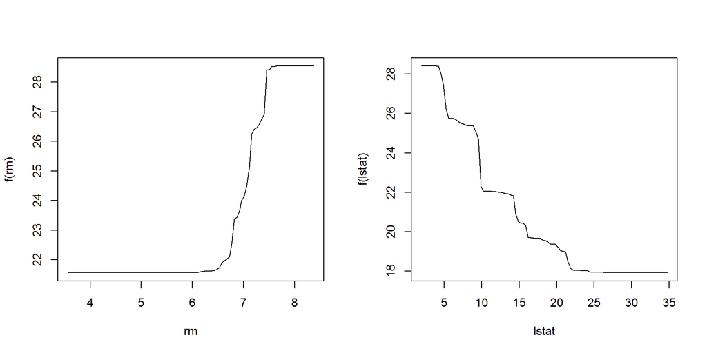

```r
par(mfrow=c(1,2))
plot(boost.boston,i="rm")
plot(boost.boston,i="lstat")
```

We now use the boosted model to predict medv on the test set:

```r
yhat.boost=predict(boost.boston,newdata=boston.test,n.trees=1000)
mean((yhat.boost-boston.test)^2)
```

```
## [1] 21187.2
```

```r
set.seed(124)
boost.boston=gbm(medv~.,data=boston.train,distribution="gaussian",n.trees=1000,interaction.depth=2,shrinkage=0.05,verbose=F)
yhat.boost=predict(boost.boston,newdata=boston.test,n.trees=1000)
mean((yhat.boost-boston.test)^2)
```

```
## [1] 21279.41
```

##### Change interaction depth and explore the prediction error

## Housing

## Heart